# R Notebook

```r
library(MVN)
mvn(data_AESTHEMOS)
```

```
## $multivariateNormality
##              Test        Statistic p value Result
## 1 Mardia Skewness 37676.4921123524       0     NO
## 2 Mardia Kurtosis 91.4617470260676       0     NO
## 3             MVN             <NA>    <NA>     NO
##
## $univariateNormality
##            Test     Variable Statistic   p value Normality
## 1  Shapiro-Wilk  challenge      0.7584  <0.001      NO
## 2  Shapiro-Wilk   delight       0.8230  <0.001      NO
## 3  Shapiro-Wilk     calm        0.8044  <0.001      NO
## 4  Shapiro-Wilk   curious       0.8691  <0.001      NO
## 5  Shapiro-Wilk    liked        0.8855  <0.001      NO
## 6  Shapiro-Wilk  fascinated     0.8388  <0.001      NO
## 7  Shapiro-Wilk  wonderful      0.7988  <0.001      NO
## 8  Shapiro-Wilk invigorated     0.7918  <0.001      NO
## 9  Shapiro-Wilk   engaged       0.8848  <0.001      NO
## 10 Shapiro-Wilk   baffled       0.6259  <0.001      NO
## 11 Shapiro-Wilk     ugly        0.5185  <0.001      NO
## 12 Shapiro-Wilk   deepmean      0.8003  <0.001      NO
## 13 Shapiro-Wilk  deepmoved      0.7391  <0.001      NO
## 14 Shapiro-Wilk melancholic     0.7099  <0.001      NO
## 15 Shapiro-Wilk  energized      0.8125  <0.001      NO
## 16 Shapiro-Wilk    angry        0.4203  <0.001      NO
## 17 Shapiro-Wilk  enchanted      0.8079  <0.001      NO
## 18 Shapiro-Wilk    bored        0.6466  <0.001      NO
## 19 Shapiro-Wilk   relaxed       0.8006  <0.001      NO
## 20 Shapiro-Wilk   insight       0.6373  <0.001      NO
## 21 Shapiro-Wilk    amused       0.7200  <0.001      NO
## 22 Shapiro-Wilk     sad         0.6487  <0.001      NO
## 23 Shapiro-Wilk   confused      0.5844  <0.001      NO
## 24 Shapiro-Wilk  aggressive     0.4791  <0.001      NO
## 25 Shapiro-Wilk sentimental     0.7221  <0.001      NO
## 26 Shapiro-Wilk   worried       0.6662  <0.001      NO
## 27 Shapiro-Wilk  nostalgic      0.7091  <0.001      NO
## 28 Shapiro-Wilk  surprised      0.7527  <0.001      NO
## 29 Shapiro-Wilk  oppressive     0.6445  <0.001      NO
## 30 Shapiro-Wilk   sublime       0.7404  <0.001      NO
## 31 Shapiro-Wilk spurredmeon     0.7457  <0.001      NO
## 32 Shapiro-Wilk indifferent     0.6362  <0.001      NO
```

[output cut: 83 more lines]

```
## surprised    -0.07160704
## oppressive    1.96067744
## sublime       0.54197639
## spurredmeon   0.57176388
## indifferent   2.78918045
## impressed    -0.49520223
## distasteful   3.80789487
## touched      -0.11192171
## unsettling    0.21998975
## sparkinterst -0.83045204
## happy        -0.57210985
## awe           1.13998384
## motivated    -0.10052630
## funny         8.46014421
## liking       -0.96130316
```

CFA with original AESTHEMOS Factors

```r
CFA_AESTHEMOS_orth.fit<-lavaan::cfa(CFA_AESTHEMOS,
                         data=data,

                      rotation='varimax',
                        orthogonal=TRUE,
                         estimator="WLSMV",
                         std.lv=TRUE)
fit_orth<-as.data.frame(fitmeasures(CFA_AESTHEMOS_orth.fit))


CFA_AESTHEMOS_obl.fit<-lavaan::cfa(CFA_AESTHEMOS,
                         data=data,

                     #  rotation='varimax',
                      #  orthogonal=TRUE,
                         estimator="WLSMV",
                         std.lv=TRUE)
fit_obl<-as.data.frame(fitmeasures(CFA_AESTHEMOS_obl.fit))


# saving fitindices to dataframe

AEST_fitmeasures<-data.frame(
  "fitindices"=c("chi square",
                 "df (chi square)",
                 "p (chi square)",
                 "cfi",
                 "tli",
                 "rmsea",
                 "agfi" ),
  "orthogonal"=c(fit_orth["chisq",], fit_orth["df",], fit_orth["pvalue",], fit_orth["cfi",], fit_orth["tli",], fit_orth["rmsea",], fit_orth["agfi",]),

  "oblimin"= c(fit_obl["chisq",], fit_obl["df",], fit_obl["pvalue",], fit_obl["cfi",], fit_obl["tli",], fit_obl["rmsea",], fit_obl["agfi",]))

# reduce to only 2 decimal places so it looks less chaotic
is.num <- sapply(AEST_fitmeasures, is.numeric)
AEST_fitmeasures[is.num] <- lapply(AEST_fitmeasures[is.num], round, 2)
```

```r
print(AEST_fitmeasures)
```

```
##        fitindices orthogonal oblimin
## 1      chi square   47130.07 8325.09
## 2 df (chi square)     819.00  798.00
## 3  p (chi square)       0.00    0.00
## 4             cfi       0.23    0.88
## 5             tli       0.20    0.87
## 6           rmsea       0.27    0.11
## 7            agfi       0.33    0.88
```

Fit

## STEP 1: determine the number of factors

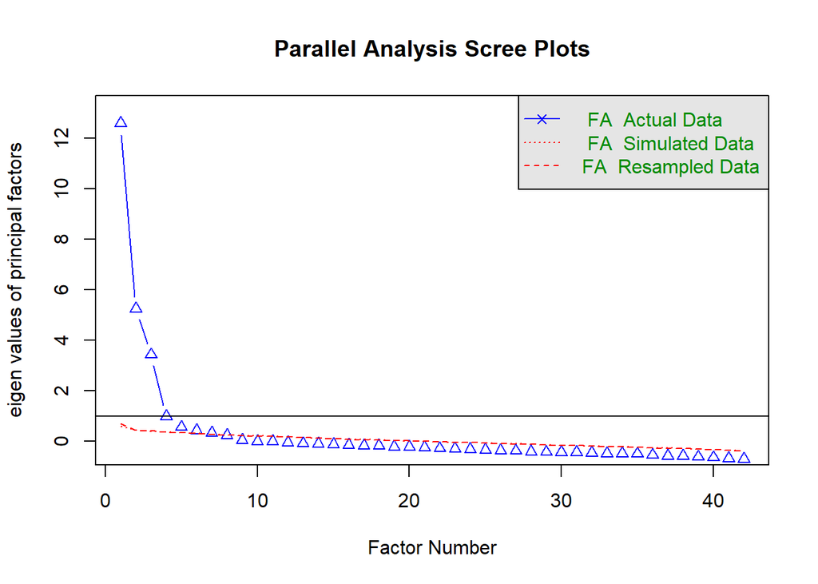

```
## Parallel analysis suggests that the number of factors =  7  and the number of components =  NA
```

```r
fa.parallel(data_AESTHEMOS,  fm="wls", fa="fa")
```

## STEP 2: Factor analysis with 7 factors (as suggested by previous parallel analysis), varimax rotation is applied, weighted least squares (WLS) is used to estimate the factors

### path diagram for the first EFA

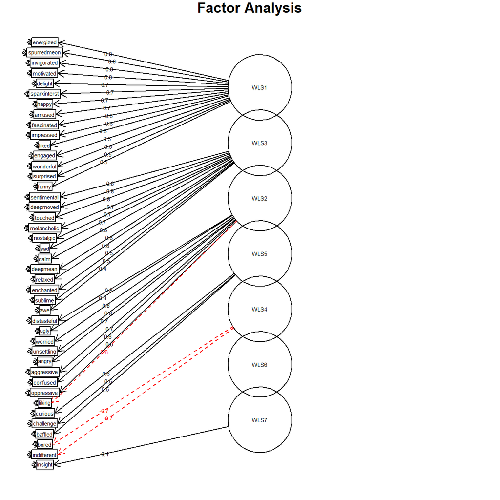

```r
#library(ggplot2)

#ggplot(EFA_results_long, aes(name,abs(loadings),fill=loadings))+
 #  facet_wrap(~factor, nrow=1)+
  # geom_bar(stat = "identity")+
  # coord_flip()+
  #scale_fill_gradient2(name="Factorloadings",high="turquoise4",mid="paleturquoise",low="salmon",    midpoint = 0, guide=F)+
  #ylab("Loading strength")+
  #xlab("Item name")+
 #theme_bw(base_size = 28)
```

The seven factor solution revealed some cross-loadings of items on several factors. Items that showed loadings on several factors with a difference of less than .20 were removed. Another EFA was carried out with the remaining items.

## to make the next step a bit simpler the retained items are saved into a new data frame

```r
EFA_reduced<-tibble(data$energized,
                    data$spurredmeon,
                    data$invigorated,
                    data$motivated,
                    data$delight,
                    data$happy,
                    data$amused,
                    data$funny,

                    data$sentimental,
                    data$deepmoved,
                    data$touched,
                    data$nostalgic,
                    data$melancholic,
                    data$sad,
                    data$deepmean,

                    data$distasteful,
                    data$ugly,
                    data$worried,
                    data$unsettling,
                    data$angry,
                    data$aggressive,
                    data$confused,
                    data$oppressive,

                    data$bored,
                    data$indifferent)

names(EFA_reduced)<-c("energized",
                    "spurredmeon",
                    "invigorated",
                    "motivated",
                    "delight",
                    "happy",
                    "amused",
                    "funny",

                    "sentimental",
                    "deepmoved",
                    "touched",
                    "nostalgic",
                    "melancholic",
                    "sad",
                    "deepmean",

                    "distasteful",
                    "ugly",
                    "worried",
                    "unsettling",
                    "angry",
                    "aggressive",
                    "confused",
                    "oppressive",
                    "bored",
                    "indifferent"
                    )


 EFA_ordered<- as.data.frame(lapply(EFA_reduced[
   ,c("energized",
      "spurredmeon",
      "invigorated",
      "motivated",
      "delight",
      "happy",
      "amused",
      "funny",

      "sentimental",
      "deepmoved",
      "touched",
      "nostalgic",
      "melancholic",
      "sad",
      "deepmean",

      "distasteful",
      "ugly",
      "worried",
      "unsettling",
      "angry",
      "aggressive",
      "confused",
      "oppressive",

      "bored",
      "indifferent"
                  )],
         ordered))
```

### second parallel analysis to determine the number of factors in the reduced data set

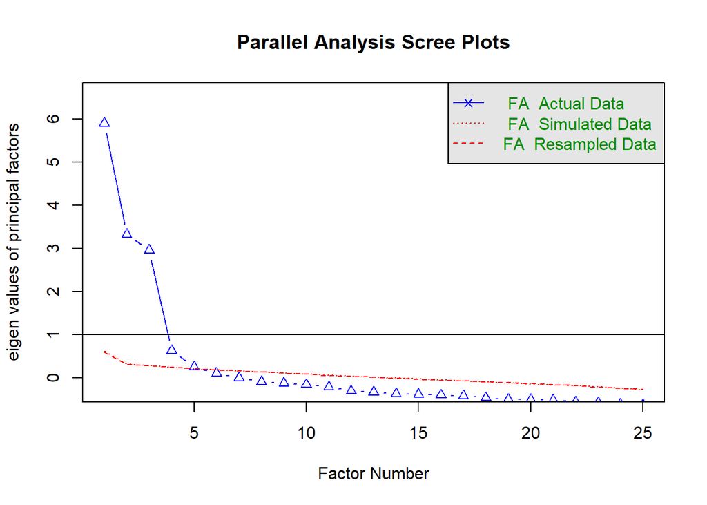

```
## Parallel analysis suggests that the number of factors =  5  and the number of components =  NA
```

```r
fa.parallel(EFA_reduced,  fm="wls", fa="fa")
```

### A second factor analysis was carried out.

```r
second_EFA<-psych::fa(EFA_reduced, nfactors = 4, rotate='varimax',fm="wls", fa="fa")

print(second_EFA, sort=TRUE, digits = 2)
```

```
## Factor Analysis using method =  wls
## Call: psych::fa(r = EFA_reduced, nfactors = 4, rotate = "varimax",
##     fm = "wls", fa = "fa")
## Standardized loadings (pattern matrix) based upon correlation matrix
##             item  WLS1  WLS2  WLS3  WLS4   h2   u2 com
## worried       18  0.83 -0.07  0.01 -0.14 0.71 0.29 1.1
## unsettling    19  0.79 -0.07 -0.08 -0.05 0.64 0.36 1.0
## distasteful   16  0.75 -0.08 -0.06  0.23 0.63 0.37 1.2
## ugly          17  0.73 -0.11 -0.13  0.21 0.61 0.39 1.3
## angry         20  0.70  0.01 -0.02  0.05 0.49 0.51 1.0
## aggressive    21  0.69  0.09 -0.03 -0.05 0.49 0.51 1.0
## oppressive    23  0.64 -0.05 -0.08  0.05 0.42 0.58 1.0
## confused      22  0.59 -0.09 -0.02  0.08 0.36 0.64 1.1
## energized      1  0.04  0.83 -0.01 -0.17 0.71 0.29 1.1
## spurredmeon    2  0.11  0.77 -0.01 -0.10 0.61 0.39 1.1
## motivated      4  0.19  0.74  0.06 -0.16 0.61 0.39 1.2
## invigorated    3  0.03  0.72  0.08 -0.08 0.54 0.46 1.1
## amused         7 -0.17  0.72  0.05 -0.03 0.55 0.45 1.1
## delight        5 -0.37  0.71  0.29 -0.09 0.74 0.26 1.9
## happy          6 -0.39  0.69  0.18 -0.04 0.67 0.33 1.8
## funny          8 -0.12  0.49 -0.13  0.07 0.28 0.72 1.3
## deepmoved     10 -0.09  0.16  0.82 -0.15 0.73 0.27 1.2
## touched       11 -0.20  0.22  0.81 -0.15 0.76 0.24 1.4
## sentimental    9 -0.22  0.02  0.78  0.01 0.66 0.34 1.2
## melancholic   13  0.05 -0.04  0.73  0.06 0.54 0.46 1.0
## nostalgic     12 -0.15  0.05  0.67 -0.02 0.47 0.53 1.1
## sad           14  0.13 -0.23  0.66  0.05 0.51 0.49 1.4
## deepmean      15  0.03  0.10  0.63 -0.21 0.45 0.55 1.3
## bored         24  0.18 -0.17 -0.14  0.73 0.61 0.39 1.3
## indifferent   25  0.04 -0.12 -0.06  0.65 0.44 0.56 1.1
##
##                       WLS1 WLS2 WLS3 WLS4
## SS loadings           4.71 4.31 3.94 1.27
## Proportion Var        0.19 0.17 0.16 0.05
## Cumulative Var        0.19 0.36 0.52 0.57
## Proportion Explained  0.33 0.30 0.28 0.09
## Cumulative Proportion 0.33 0.63 0.91 1.00
##
## Mean item complexity =  1.2
## Test of the hypothesis that 4 factors are sufficient.
##
## The degrees of freedom for the null model are  300  and the objective function was  15.55 with Chi Square of  11741.28
## The degrees of freedom for the model are 206  and the objective function was  2.21
##
## The root mean square of the residuals (RMSR) is  0.04
## The df corrected root mean square of the residuals is  0.05
##
## The harmonic number of observations is  765 with the empirical chi square  692.04  with prob <  7.6e-54
## The total number of observations was  765  with Likelihood Chi Square =  1664.85  with prob <  2.7e-226
##
## Tucker Lewis Index of factoring reliability =  0.814
## RMSEA index =  0.096  and the 90 % confidence intervals are  0.092 0.101
## BIC =  297.03
## Fit based upon off diagonal values = 0.98
## Measures of factor score adequacy
##                                                   WLS1 WLS2 WLS3 WLS4
## Correlation of (regression) scores with factors   0.96 0.96 0.95 0.84
## Multiple R square of scores with factors          0.92 0.91 0.91 0.71
## Minimum correlation of possible factor scores     0.83 0.82 0.82 0.42
```

A CFA is carried out to confirm the EFA model with four factors.

```r
require(parameters)
if (require("psych") && require("lavaan"))


  #this model gets rejected
  model1<-'
  M1=~worried+ unsettling+distasteful + ugly
  M2=~energized + spurredmeon + motivated + invigorated
  M3=~deepmoved+touched+sentimental+melancholic
  M4=~bored+indifferent'

 model1.fit<-lavaan::cfa(model1,
                         data=EFA_reduced,
                         rotation='varimax',
                         orthogonal=TRUE,
                         estimator="WLSMV",
                         std.lv=TRUE)
#summary(model1.fit)
```

This model is rejected. As the measures for factor adequacy are comparatively low and there are only two items loading in that factor, another CFA was carried out with only the first major 3 factors.

```r
  # this model works
  model2<-'
  M1=~worried+ unsettling+distasteful + ugly
  M2=~energized + spurredmeon + motivated + invigorated
  M3=~deepmoved+touched+sentimental+melancholic '

 model2.fit<-lavaan::cfa(model2,
                         data=EFA_ordered,
                         rotation='varimax',
                         orthogonal=TRUE,
                         estimator="WLSMV",
                         std.lv=TRUE)

fitmeasures(model2.fit)
```

```
##                          npar                          fmin
##                        60.000                         0.689
##                         chisq                            df
##                      1054.687                        54.000
##                        pvalue                  chisq.scaled
##                         0.000                       576.540
##                     df.scaled                 pvalue.scaled
##                        54.000                         0.000
##          chisq.scaling.factor                baseline.chisq
##                         1.922                     27880.197
##                   baseline.df               baseline.pvalue
##                        66.000                         0.000
##         baseline.chisq.scaled            baseline.df.scaled
##                     14383.934                        66.000
##        baseline.pvalue.scaled baseline.chisq.scaling.factor
##                         0.000                         1.943
##                           cfi                           tli
##                         0.964                         0.956
##                          nnfi                           rfi
##                         0.956                         0.954
##                           nfi                          pnfi
##                         0.962                         0.787
##                           ifi                           rni
##                         0.964                         0.964
##                    cfi.scaled                    tli.scaled
##                         0.964                         0.955
##                    cfi.robust                    tli.robust
##                            NA                            NA
##                   nnfi.scaled                   nnfi.robust
##                         0.955                            NA
##                    rfi.scaled                    nfi.scaled
##                         0.951                         0.960
##                    ifi.scaled                    rni.scaled
##                         0.964                         0.964
##                    rni.robust                         rmsea
##                            NA                         0.156
##                rmsea.ci.lower                rmsea.ci.upper
##                         0.148                         0.164
##                  rmsea.pvalue                  rmsea.scaled
##                         0.000                         0.113
##         rmsea.ci.lower.scaled         rmsea.ci.upper.scaled
##                         0.104                         0.121
##           rmsea.pvalue.scaled                  rmsea.robust
##                         0.000                            NA
##         rmsea.ci.lower.robust         rmsea.ci.upper.robust
##                            NA                            NA
##           rmsea.pvalue.robust                           rmr
##                            NA                         0.154
##                    rmr_nomean                          srmr
##                         0.165                         0.165
##                  srmr_bentler           srmr_bentler_nomean
##                         0.154                         0.165
##                          crmr                   crmr_nomean
##                         0.165                         0.180
##                    srmr_mplus             srmr_mplus_nomean
##                         0.154                         0.165
##                         cn_05                         cn_01
##                        53.267                        59.725
##                           gfi                          agfi
##                         0.974                         0.946
##                          pgfi                           mfi
##                         0.462                         0.519
```

```r
summary(model2.fit)
```

```
## lavaan 0.6-5 ended normally after 19 iterations
##
##   Estimator                                       DWLS
##   Optimization method                           NLMINB
##   Number of free parameters                         60
##
##   Number of observations                           765
##
## Model Test User Model:
##                                               Standard      Robust
##   Test Statistic                              1054.687     576.540
##   Degrees of freedom                                54          54
##   P-value (Chi-square)                           0.000       0.000
##   Scaling correction factor                                  1.922
##   Shift parameter                                           27.717
##     for the simple second-order correction
##
## Parameter Estimates:
##
##   Information                                 Expected
##   Information saturated (h1) model        Unstructured
##   Standard errors                           Robust.sem
##
## Latent Variables:
##                    Estimate  Std.Err  z-value  P(>|z|)
##   M1 =~
##     worried           0.871    0.018   48.569    0.000
##     unsettling        0.891    0.016   55.541    0.000
##     distasteful       0.902    0.016   58.186    0.000
##     ugly              0.909    0.015   58.660    0.000
##   M2 =~
##     energized         0.923    0.011   84.547    0.000
##     spurredmeon       0.860    0.014   62.725    0.000
##     motivated         0.849    0.015   56.867    0.000
##     invigorated       0.816    0.016   50.052    0.000
##   M3 =~
##     deepmoved         0.937    0.012   80.970    0.000
##     touched           0.938    0.012   81.503    0.000
##     sentimental       0.797    0.018   44.033    0.000
##     melancholic       0.735    0.024   30.929    0.000
```

[output cut: 95 more lines]

```
##
## Scales y*:
##                    Estimate  Std.Err  z-value  P(>|z|)
##     worried           1.000
##     unsettling        1.000
##     distasteful       1.000
##     ugly              1.000
##     energized         1.000
##     spurredmeon       1.000
##     motivated         1.000
##     invigorated       1.000
##     deepmoved         1.000
##     touched           1.000
##     sentimental       1.000
##     melancholic       1.000
```

```r
factorscores<-lavPredict(model2.fit)
lavaan::inspect(model2.fit, 'r2')
```

```
##     worried  unsettling distasteful        ugly   energized spurredmeon
##       0.759       0.794       0.814       0.826       0.852       0.740
##   motivated invigorated   deepmoved     touched sentimental melancholic
##       0.721       0.665       0.877       0.879       0.635       0.541
```

```r
var<-mean(lavaan::lavInspect(model2.fit, 'r2'))

lavaan::inspectSampleCov(model=model2, data=EFA_ordered)
```

```
## $cov
##             worrid unsttl dststf ugly   enrgzd sprrdm motvtd invgrt depmvd
## worried      1.000
## unsettling   0.833  1.000
## distasteful  0.700  0.740  1.000
## ugly         0.693  0.728  0.875  1.000
## energized    0.007 -0.007 -0.137 -0.247  1.000
## spurredmeon  0.062  0.029 -0.055 -0.120  0.770  1.000
## motivated    0.157  0.128 -0.002 -0.100  0.793  0.747  1.000
## invigorated -0.004  0.007 -0.053 -0.177  0.763  0.717  0.646  1.000
## deepmoved   -0.153 -0.221 -0.309 -0.452  0.177  0.178  0.230  0.192  1.000
## touched     -0.278 -0.334 -0.406 -0.533  0.186  0.159  0.230  0.223  0.887
## sentimental -0.266 -0.343 -0.320 -0.487 -0.003 -0.024 -0.050  0.149  0.717
## melancholic  0.054 -0.043  0.007 -0.102 -0.051 -0.022  0.045  0.046  0.675
##             touchd sntmnt mlnchl
## worried
## unsettling
## distasteful
## ugly
## energized
## spurredmeon
## motivated
## invigorated
## deepmoved
## touched      1.000
## sentimental  0.740  1.000
## melancholic  0.632  0.664  1.000
##
## $mean
##     worried  unsettling distasteful        ugly   energized spurredmeon
##           0           0           0           0           0           0
##   motivated invigorated   deepmoved     touched sentimental melancholic
##           0           0           0           0           0           0
##
## $th
##     worried|t1     worried|t2     worried|t3     worried|t4  unsettling|t1
##          0.395          0.796          1.207          1.843          0.243
##  unsettling|t2  unsettling|t3  unsettling|t4 distasteful|t1 distasteful|t2
##          0.659          1.018          1.501          0.730          1.111
## distasteful|t3 distasteful|t4        ugly|t1        ugly|t2        ugly|t3
##          1.425          1.899          0.765          1.135          1.443
##        ugly|t4   energized|t1   energized|t2   energized|t3   energized|t4
##          1.792         -0.126          0.399          1.007          1.543
## spurredmeon|t1 spurredmeon|t2 spurredmeon|t3 spurredmeon|t4   motivated|t1
##          0.133          0.696          1.293          1.843          0.051
##   motivated|t2   motivated|t3   motivated|t4 invigorated|t1 invigorated|t2
##          0.557          1.041          1.611         -0.015          0.445
## invigorated|t3 invigorated|t4   deepmoved|t1   deepmoved|t2   deepmoved|t3
##          1.052          1.730          0.126          0.713          1.193
##   deepmoved|t4     touched|t1     touched|t2     touched|t3     touched|t4
##          1.674          0.044          0.580          1.035          1.688
## sentimental|t1 sentimental|t2 sentimental|t3 sentimental|t4 melancholic|t1
##          0.210          0.726          1.161          1.843          0.253
## melancholic|t2 melancholic|t3 melancholic|t4
##          0.809          1.364          1.963
```

```r
#lavaan::inspectSampleCov(data=model2.fit)
lavPredict(model2.fit,se="standard")
```

```
##            M1     M2     M3
##   [1,] -0.490  0.326 -0.718
##   [2,]  0.409  0.175  0.459
##   [3,] -0.490  2.421  1.311
##   [4,]  0.990 -0.267 -0.718
##   [5,]  0.916  0.812  0.464
##   [6,] -0.490 -0.880 -0.718
##   [7,]  0.103  0.394  0.217
##   [8,] -0.490  0.930 -0.079
##   [9,]  0.770 -0.880 -0.718
##  [10,]  1.178 -0.880 -0.718
##  [11,]  0.091  0.705 -0.718
##  [12,]  0.464  0.587  0.464
##  [13,]  1.054 -0.880 -0.718
##  [14,]  0.350 -0.880 -0.319
```

[output cut: 751 more lines]

```r
CFA_factorscores<-lavPredict(model2.fit)
summary(model2.fit, rsquare = TRUE)
```

```
## lavaan 0.6-5 ended normally after 19 iterations
##
##   Estimator                                       DWLS
##   Optimization method                           NLMINB
##   Number of free parameters                         60
##
##   Number of observations                           765
##
## Model Test User Model:
##                                               Standard      Robust
##   Test Statistic                              1054.687     576.540
##   Degrees of freedom                                54          54
##   P-value (Chi-square)                           0.000       0.000
##   Scaling correction factor                                  1.922
##   Shift parameter                                           27.717
##     for the simple second-order correction
##
## Parameter Estimates:
##
##   Information                                 Expected
##   Information saturated (h1) model        Unstructured
##   Standard errors                           Robust.sem
##
## Latent Variables:
##                    Estimate  Std.Err  z-value  P(>|z|)
##   M1 =~
##     worried           0.871    0.018   48.569    0.000
##     unsettling        0.891    0.016   55.541    0.000
##     distasteful       0.902    0.016   58.186    0.000
##     ugly              0.909    0.015   58.660    0.000
##   M2 =~
##     energized         0.923    0.011   84.547    0.000
##     spurredmeon       0.860    0.014   62.725    0.000
##     motivated         0.849    0.015   56.867    0.000
##     invigorated       0.816    0.016   50.052    0.000
##   M3 =~
##     deepmoved         0.937    0.012   80.970    0.000
##     touched           0.938    0.012   81.503    0.000
##     sentimental       0.797    0.018   44.033    0.000
##     melancholic       0.735    0.024   30.929    0.000
```

[output cut: 110 more lines]

```
##
## R-Square:
##                    Estimate
##     worried           0.759
##     unsettling        0.794
##     distasteful       0.814
##     ugly              0.826
##     energized         0.852
##     spurredmeon       0.740
##     motivated         0.721
##     invigorated       0.665
##     deepmoved         0.877
##     touched           0.879
##     sentimental       0.635
##     melancholic       0.541
```

The second model fits well, the RMSEA and SRMR are higher than the cutoff value, however, these values are based on normal continuous data and it has been discussed that these are not as appropriate for non-normal ordinal data - as the other fitindices indicate good fit and the items that are loading on these factors make sense, we accept the model.

```r
lavaan.diagram(model2.fit, e.size=0.055, errors=TRUE, regression=TRUE)
#sem.graph(CFA7.modelfit)
#sem.diagram(CFA7.modelfit)
```

[output not shown]

```r
F1<-tibble(EFA_reduced$worried, EFA_reduced$unsettling, EFA_reduced$distasteful, EFA_reduced$ugly)

F2<-tibble(EFA_reduced$sentimental, EFA_reduced$deepmoved, EFA_reduced$touched, EFA_reduced$melancholic)

F3<-tibble(EFA_reduced$energized, EFA_reduced$spurredmeon, EFA_reduced$invigorated, EFA_reduced$motivated)

F1_alpha<-psych::alpha(x=F1)
F2_alpha<-psych::alpha(x=F2)
F3_alpha<-psych::alpha(x=F3)
```

```r
F1_alpha
```

```
##
## Reliability analysis
## Call: psych::alpha(x = F1)
##
##   raw_alpha std.alpha G6(smc) average_r S/N    ase mean   sd median_r
##       0.87      0.87    0.87      0.64   7 0.0077  1.6 0.94     0.59
##
##  lower alpha upper     95% confidence boundaries
## 0.86 0.87 0.89
##
##  Reliability if an item is dropped:
##                         raw_alpha std.alpha G6(smc) average_r S/N alpha se
## EFA_reduced$worried          0.84      0.85    0.81      0.66 5.7   0.0103
## EFA_reduced$unsettling       0.83      0.84    0.79      0.63 5.1   0.0109
## EFA_reduced$distasteful      0.83      0.83    0.78      0.63 5.1   0.0100
## EFA_reduced$ugly             0.83      0.84    0.78      0.63 5.1   0.0099
##                          var.r med.r
## EFA_reduced$worried     0.0114  0.59
## EFA_reduced$unsettling  0.0164  0.56
## EFA_reduced$distasteful 0.0091  0.59
## EFA_reduced$ugly        0.0087  0.59
##
##  Item statistics
##                           n raw.r std.r r.cor r.drop mean  sd
## EFA_reduced$worried     765  0.85  0.84  0.76   0.72  1.7 1.1
## EFA_reduced$unsettling  765  0.88  0.86  0.80   0.74  1.9 1.3
## EFA_reduced$distasteful 765  0.84  0.86  0.81   0.73  1.5 1.0
## EFA_reduced$ugly        765  0.84  0.86  0.81   0.73  1.5 1.0
##
## Non missing response frequency for each item
##                            1    2    3    4    5 miss
## EFA_reduced$worried     0.65 0.13 0.10 0.08 0.03    0
## EFA_reduced$unsettling  0.60 0.15 0.10 0.09 0.07    0
## EFA_reduced$distasteful 0.77 0.10 0.06 0.05 0.03    0
## EFA_reduced$ugly        0.78 0.09 0.05 0.04 0.04    0
```

```r
F2_alpha
```

```
##
## Reliability analysis
## Call: psych::alpha(x = F2)
##
##   raw_alpha std.alpha G6(smc) average_r S/N    ase mean   sd median_r
##       0.87      0.87    0.85      0.62 6.6 0.0076  1.8 0.97     0.59
##
##  lower alpha upper     95% confidence boundaries
## 0.86 0.87 0.89
##
##  Reliability if an item is dropped:
##                         raw_alpha std.alpha G6(smc) average_r S/N alpha se
## EFA_reduced$sentimental      0.85      0.84    0.81      0.64 5.4   0.0097
## EFA_reduced$deepmoved        0.80      0.80    0.74      0.58 4.1   0.0121
## EFA_reduced$touched          0.81      0.81    0.74      0.58 4.2   0.0121
## EFA_reduced$melancholic      0.87      0.87    0.84      0.69 6.8   0.0081
##                           var.r med.r
## EFA_reduced$sentimental 0.02395  0.57
## EFA_reduced$deepmoved   0.00354  0.55
## EFA_reduced$touched     0.00098  0.57
## EFA_reduced$melancholic 0.01228  0.65
##
##  Item statistics
##                           n raw.r std.r r.cor r.drop mean  sd
## EFA_reduced$sentimental 765  0.83  0.83  0.74   0.69  1.8 1.1
## EFA_reduced$deepmoved   765  0.89  0.89  0.87   0.80  1.9 1.2
## EFA_reduced$touched     765  0.89  0.89  0.87   0.79  2.0 1.2
## EFA_reduced$melancholic 765  0.77  0.79  0.66   0.62  1.7 1.1
##
## Non missing response frequency for each item
##                            1    2    3    4    5 miss
## EFA_reduced$sentimental 0.58 0.18 0.11 0.09 0.03    0
## EFA_reduced$deepmoved   0.55 0.21 0.12 0.07 0.05    0
## EFA_reduced$touched     0.52 0.20 0.13 0.10 0.05    0
## EFA_reduced$melancholic 0.60 0.19 0.12 0.06 0.02    0
```

```r
F3_alpha
```

```
##
## Reliability analysis
## Call: psych::alpha(x = F3)
##
##   raw_alpha std.alpha G6(smc) average_r S/N    ase mean sd median_r
##       0.88      0.88    0.85      0.65 7.4 0.0071    2  1     0.67
##
##  lower alpha upper     95% confidence boundaries
## 0.87 0.88 0.89
##
##  Reliability if an item is dropped:
##                         raw_alpha std.alpha G6(smc) average_r S/N alpha se
## EFA_reduced$energized        0.82      0.82    0.76      0.61 4.6   0.0114
## EFA_reduced$spurredmeon      0.84      0.84    0.80      0.64 5.4   0.0098
## EFA_reduced$invigorated      0.87      0.87    0.82      0.69 6.6   0.0082
## EFA_reduced$motivated        0.85      0.85    0.80      0.66 5.8   0.0092
##                           var.r med.r
## EFA_reduced$energized   0.00345  0.61
## EFA_reduced$spurredmeon 0.00790  0.68
## EFA_reduced$invigorated 0.00069  0.69
## EFA_reduced$motivated   0.00150  0.68
##
##  Item statistics
##                           n raw.r std.r r.cor r.drop mean  sd
## EFA_reduced$energized   765  0.90  0.90  0.86   0.81  2.1 1.2
## EFA_reduced$spurredmeon 765  0.85  0.86  0.80   0.75  1.8 1.1
## EFA_reduced$invigorated 765  0.83  0.83  0.74   0.69  2.0 1.2
## EFA_reduced$motivated   765  0.85  0.85  0.78   0.73  2.0 1.2
##
## Non missing response frequency for each item
##                            1    2    3    4    5 miss
## EFA_reduced$energized   0.45 0.21 0.19 0.10 0.06    0
## EFA_reduced$spurredmeon 0.55 0.20 0.15 0.07 0.03    0
## EFA_reduced$invigorated 0.49 0.18 0.18 0.10 0.04    0
## EFA_reduced$motivated   0.52 0.19 0.14 0.10 0.05    0
```

Internal consistncy for all factors is very high. (not really surprising)

## The factor scores are extracted using the weighted least score mean and variance (WLSMV) estimation method.

```r
CFA_factorscores<-lavPredict(model2.fit)
```

```r
## loop over factors
idxframe<-data.frame(as.integer(rownames(data)))
idx <- idxframe[,1]
for (fs in colnames(CFA_factorscores)) {
  data[idx, fs] <- CFA_factorscores[ , fs]
}
```

Next step: z-standardise all variables (factors and predictors)

# Step 4: Hierarchichal Linear Models for all 3 Factors

## Subjective Ratings Factor 1

[predictors with t < 1 were excluded]

# full model

Anova Factor 1

```
## Type III Analysis of Variance Table with Satterthwaite's method
##                        Sum Sq Mean Sq NumDF  DenDF F value    Pr(>F)
## Z_Neutral_FaceMeanDIV 12.3461 12.3461     1 664.47 15.4837 9.198e-05 ***
## Z_Sadness_FaceMeanDIV  2.9163  2.9163     1 664.88  3.6575   0.05625 .
## Z_Anger_FaceMeanDIV   17.0421 17.0421     1 666.44 21.3732 4.541e-06 ***
## Z_Fear_FaceMeanDIV     3.8646  3.8646     1 710.93  4.8467   0.02802 *
## Z_Disgust_FaceMeanDIV  1.3799  1.3799     1 674.55  1.7306   0.18878
## Z_meanAccelB           3.2414  3.2414     1 543.78  4.0651   0.04427 *
## Z_meanSUM_N_IncAB     14.9667 14.9667     1 683.72 18.7703 1.696e-05 ***
## Z_meanSUM_IncAB        1.2689  1.2689     1 688.29  1.5914   0.20756
## ---
## Signif. codes:  0 '***' 0.001 '**' 0.01 '*' 0.05 '.' 0.1 ' ' 1
```

Model Summary Factor 1

```
## Linear mixed model fit by maximum likelihood . t-tests use Satterthwaite's
##   method [lmerModLmerTest]
## Formula:
## ZCFA_F1 ~ Z_Neutral_FaceMeanDIV + Z_Sadness_FaceMeanDIV + Z_Anger_FaceMeanDIV +
##     Z_Fear_FaceMeanDIV + Z_Disgust_FaceMeanDIV + Z_meanAccelB +
##     Z_meanSUM_N_IncAB + Z_meanSUM_IncAB + (1 | ID)
##    Data: ZnewFA_data
##
##      AIC      BIC   logLik deviance df.resid
##   1932.8   1983.1   -955.4   1910.8      700
##
## Scaled residuals:
##     Min      1Q  Median      3Q     Max
## -1.7268 -0.7681 -0.2315  0.6985  3.6620
##
## Random effects:
##  Groups   Name        Variance Std.Dev.
##  ID       (Intercept) 0.1126   0.3355
##  Residual             0.7974   0.8929
## Number of obs: 711, groups:  ID, 48
##
## Fixed effects:
##                         Estimate Std. Error         df t value Pr(>|t|)
## (Intercept)            -0.005803   0.058933  47.524157  -0.098   0.9220
## Z_Neutral_FaceMeanDIV  -0.135770   0.034504 664.468854  -3.935 9.20e-05 ***
## Z_Sadness_FaceMeanDIV  -0.065990   0.034505 664.879087  -1.912   0.0562 .
## Z_Anger_FaceMeanDIV     0.180443   0.039031 666.444099   4.623 4.54e-06 ***
## Z_Fear_FaceMeanDIV     -0.085672   0.038915 710.931512  -2.202   0.0280 *
## Z_Disgust_FaceMeanDIV  -0.054546   0.041463 674.550386  -1.316   0.1888
## Z_meanAccelB            0.079999   0.039678 543.780898   2.016   0.0443 *
## Z_meanSUM_N_IncAB      -0.163641   0.037771 683.715305  -4.332 1.70e-05 ***
## Z_meanSUM_IncAB        -0.041952   0.033256 688.287603  -1.261   0.2076
## ---
## Signif. codes:  0 '***' 0.001 '**' 0.01 '*' 0.05 '.' 0.1 ' ' 1
##
## Correlation of Fixed Effects:
##             (Intr) Z_N_FM Z_S_FM Z_A_FM Z_F_FM Z_D_FM Z_mnAB Z_SUM_N
## Z_Ntr_FMDIV  0.001
## Z_Sdn_FMDIV  0.000  0.146
## Z_Ang_FMDIV  0.000  0.102  0.186
## Z_Fr_FcMDIV -0.011  0.151  0.014  0.025
## Z_Dsg_FMDIV -0.005 -0.065 -0.090 -0.447 -0.334
## Z_meanAcclB -0.004  0.005  0.061  0.089 -0.006 -0.044
## Z_SUM_N_IAB -0.013 -0.008  0.034 -0.053 -0.025  0.060  0.054
## Z_mnSUM_IAB -0.001 -0.024 -0.050 -0.102  0.002  0.047  0.012 -0.015
```

Confidence Intervals Factor 1

```
##                              2.5 %       97.5 %
## .sig01                          NA           NA
## .sigma                          NA           NA
## (Intercept)           -0.121309795  0.109703764
## Z_Neutral_FaceMeanDIV -0.203396622 -0.068144160
## Z_Sadness_FaceMeanDIV -0.133618816  0.001639265
## Z_Anger_FaceMeanDIV    0.103944486  0.256941522
## Z_Fear_FaceMeanDIV    -0.161943499 -0.009400263
## Z_Disgust_FaceMeanDIV -0.135811644  0.026719781
## Z_meanAccelB           0.002231894  0.157765349
## Z_meanSUM_N_IncAB     -0.237671038 -0.089611865
## Z_meanSUM_IncAB       -0.107132993  0.023228185
```

Anova Factor 2

```
## Type III Analysis of Variance Table with Satterthwaite's method
##                        Sum Sq Mean Sq NumDF  DenDF F value   Pr(>F)
## Z_Neutral_FaceMeanDIV  7.2296  7.2296     1 664.03 10.2690 0.001418 **
## Z_Happy_FaceMeanDIV    4.5122  4.5122     1 663.58  6.4092 0.011583 *
## Z_Sadness_FaceMeanDIV  4.1735  4.1735     1 663.47  5.9280 0.015164 *
## Z_Surprise_FaceMeanDIV 1.1976  1.1976     1 668.02  1.7011 0.192588
## Z_Fear_FaceMeanDIV     2.1611  2.1611     1 667.55  3.0696 0.080226 .
## Z_meangsrB             2.3411  2.3411     1 110.87  3.3254 0.070913 .
## Z_meanSUM_N_IncAB      5.2355  5.2355     1 710.79  7.4365 0.006549 **
## ---
## Signif. codes:  0 '***' 0.001 '**' 0.01 '*' 0.05 '.' 0.1 ' ' 1
```

Model Summary Factor 2

```
## Linear mixed model fit by maximum likelihood . t-tests use Satterthwaite's
##   method [lmerModLmerTest]
## Formula:
## ZCFA_F2 ~ Z_Neutral_FaceMeanDIV + Z_Happy_FaceMeanDIV + Z_Sadness_FaceMeanDIV +
##     Z_Surprise_FaceMeanDIV + Z_Fear_FaceMeanDIV + Z_meangsrB +
##     Z_meanSUM_N_IncAB + (1 | ID)
##    Data: ZnewFA_data
##
##      AIC      BIC   logLik deviance df.resid
##   1874.8   1920.5   -927.4   1854.8      701
##
## Scaled residuals:
##     Min      1Q  Median      3Q     Max
## -2.3542 -0.7126 -0.1228  0.6387  3.0154
##
## Random effects:
##  Groups   Name        Variance Std.Dev.
##  ID       (Intercept) 0.2421   0.4920
##  Residual             0.7040   0.8391
## Number of obs: 711, groups:  ID, 48
##
## Fixed effects:
##                         Estimate Std. Error        df t value Pr(>|t|)
## (Intercept)              0.01248    0.07782  47.96513   0.160  0.87326
## Z_Neutral_FaceMeanDIV    0.10432    0.03255 664.02853   3.205  0.00142 **
## Z_Happy_FaceMeanDIV      0.08179    0.03231 663.57942   2.532  0.01158 *
## Z_Sadness_FaceMeanDIV   -0.07841    0.03220 663.46772  -2.435  0.01516 *
## Z_Surprise_FaceMeanDIV  -0.12649    0.09698 668.01881  -1.304  0.19259
## Z_Fear_FaceMeanDIV       0.17048    0.09731 667.55044   1.752  0.08023 .
## Z_meangsrB               0.12175    0.06677 110.87211   1.824  0.07091 .
## Z_meanSUM_N_IncAB        0.09954    0.03650 710.79345   2.727  0.00655 **
## ---
## Signif. codes:  0 '***' 0.001 '**' 0.01 '*' 0.05 '.' 0.1 ' ' 1
##
## Correlation of Fixed Effects:
##             (Intr) Z_N_FM Z_H_FM Z_Sd_FMDIV Z_Sr_FMDIV Z_F_FM Z_mngB
## Z_Ntr_FMDIV  0.002
## Z_Hpp_FMDIV  0.000  0.103
## Z_Sdn_FMDIV  0.000  0.144  0.154
## Z_Srp_FMDIV -0.001 -0.093 -0.069 -0.022
## Z_Fr_FcMDIV -0.004  0.136  0.034  0.018     -0.932
## Z_meangsrB   0.049  0.015 -0.008  0.010      0.041     -0.027
## Z_SUM_N_IAB -0.008 -0.010 -0.045  0.035      0.048     -0.048  0.010
```

Confidence Intervals Factor 2

```
##                               2.5 %      97.5 %
## .sig01                           NA          NA
## .sigma                           NA          NA
## (Intercept)            -0.140037897  0.16499808
## Z_Neutral_FaceMeanDIV   0.040516357  0.16812848
## Z_Happy_FaceMeanDIV     0.018469999  0.14511892
## Z_Sadness_FaceMeanDIV  -0.141524891 -0.01528993
## Z_Surprise_FaceMeanDIV -0.316570820  0.06358946
## Z_Fear_FaceMeanDIV     -0.020232568  0.36120160
## Z_meangsrB             -0.009107525  0.25261023
## Z_meanSUM_N_IncAB       0.027998874  0.17108667
```

Anova Factor 3

```
## Type III Analysis of Variance Table with Satterthwaite's method
##                        Sum Sq Mean Sq NumDF  DenDF F value   Pr(>F)
## Z_Neutral_FaceMeanDIV  1.6131  1.6131     1 664.68  2.2375 0.135172
## Z_Sadness_FaceMeanDIV  6.4852  6.4852     1 661.96  8.9958 0.002808 **
## Z_Anger_FaceMeanDIV    3.4769  3.4769     1 670.15  4.8229 0.028426 *
## Z_meanAccelB          11.5900 11.5900     1 695.55 16.0768 6.74e-05 ***
## Z_meangsrB             5.0442  5.0442     1 113.30  6.9970 0.009324 **
## Z_meanSUM_N_IncAB      1.0026  1.0026     1 710.83  1.3907 0.238678
## Z_meanbvpAmpB          0.9981  0.9981     1 245.06  1.3845 0.240472
## ---
## Signif. codes:  0 '***' 0.001 '**' 0.01 '*' 0.05 '.' 0.1 ' ' 1
```

Model Summary Factor 3

```
## Linear mixed model fit by maximum likelihood . t-tests use Satterthwaite's
##   method [lmerModLmerTest]
## Formula:
## ZCFA_F3 ~ Z_Neutral_FaceMeanDIV + Z_Sadness_FaceMeanDIV + Z_Anger_FaceMeanDIV +
##     Z_meanAccelB + Z_meangsrB + Z_meanSUM_N_IncAB + Z_meanbvpAmpB +
##     (1 | ID)
##    Data: ZnewFA_data
##
##      AIC      BIC   logLik deviance df.resid
##   1891.0   1936.7   -935.5   1871.0      701
##
## Scaled residuals:
##     Min      1Q  Median      3Q     Max
## -1.8359 -0.7536 -0.1693  0.6822  3.3718
##
## Random effects:
##  Groups   Name        Variance Std.Dev.
##  ID       (Intercept) 0.2437   0.4937
##  Residual             0.7209   0.8491
## Number of obs: 711, groups:  ID, 48
##
## Fixed effects:
##                        Estimate Std. Error        df t value Pr(>|t|)
## (Intercept)             0.01681    0.07827  45.71923   0.215  0.83094
## Z_Neutral_FaceMeanDIV   0.04857    0.03247 664.67838   1.496  0.13517
## Z_Sadness_FaceMeanDIV   0.09794    0.03265 661.96395   2.999  0.00281 **
## Z_Anger_FaceMeanDIV    -0.07206    0.03281 670.15326  -2.196  0.02843 *
## Z_meanAccelB           -0.16075    0.04009 695.54989  -4.010 6.74e-05 ***
## Z_meangsrB              0.18146    0.06860 113.30270   2.645  0.00932 **
## Z_meanSUM_N_IncAB       0.04353    0.03691 710.82965   1.179  0.23868
## Z_meanbvpAmpB          -0.06677    0.05674 245.05872  -1.177  0.24047
## ---
## Signif. codes:  0 '***' 0.001 '**' 0.01 '*' 0.05 '.' 0.1 ' ' 1
##
## Correlation of Fixed Effects:
##             (Intr) Z_N_FM Z_S_FM Z_A_FM Z_mnAcB Z_mngB Z_SUM_
## Z_Ntr_FMDIV  0.002
## Z_Sdn_FMDIV  0.000  0.143
## Z_Ang_FMDIV -0.002  0.098  0.160
## Z_meanAcclB -0.010  0.005  0.060  0.078
## Z_meangsrB   0.056  0.010  0.008  0.014 -0.137
## Z_SUM_N_IAB -0.009 -0.004  0.039 -0.035  0.045   0.003
## Z_mnbvpAmpB -0.044  0.036 -0.010 -0.030  0.002  -0.149 -0.004
```

Confidence Intervals Factor 3

```
##                             2.5 %       97.5 %
## .sig01                         NA           NA
## .sigma                         NA           NA
## (Intercept)           -0.13659685  0.170207738
## Z_Neutral_FaceMeanDIV -0.01507197  0.112221709
## Z_Sadness_FaceMeanDIV  0.03393778  0.161936328
## Z_Anger_FaceMeanDIV   -0.13637740 -0.007748865
## Z_meanAccelB          -0.23932729 -0.082172105
## Z_meangsrB             0.04700638  0.315918367
## Z_meanSUM_N_IncAB     -0.02881421  0.115867488
## Z_meanbvpAmpB         -0.17797835  0.044446066
```

Anova Happy

```
## Type III Analysis of Variance Table with Satterthwaite's method
##                         Sum Sq Mean Sq NumDF  DenDF F value    Pr(>F)
## Z_Neutral_FaceMeanDIV  14.6701 14.6701     1 660.85 17.8153 2.775e-05 ***
## Z_Happy_FaceMeanDIV     5.1896  5.1896     1 662.71  6.3023  0.012295 *
## Z_Anger_FaceMeanDIV     7.7156  7.7156     1 662.66  9.3698  0.002295 **
## Z_Surprise_FaceMeanDIV  2.7063  2.7063     1 670.27  3.2865  0.070297 .
## Z_Fear_FaceMeanDIV      3.2556  3.2556     1 669.85  3.9536  0.047178 *
## Z_Disgust_FaceMeanDIV   1.2699  1.2699     1 670.02  1.5422  0.214730
## Z_meanAccelB            1.3408  1.3408     1 538.44  1.6283  0.202490
## Z_meanSUM_N_IncAB      19.6465 19.6465     1 684.22 23.8586 1.292e-06 ***
## Z_meanSUM_IncAB         1.5174  1.5174     1 689.65  1.8428  0.175071
## ---
## Signif. codes:  0 '***' 0.001 '**' 0.01 '*' 0.05 '.' 0.1 ' ' 1
```

Model Summary Happy

```
## Linear mixed model fit by maximum likelihood . t-tests use Satterthwaite's
##   method [lmerModLmerTest]
## Formula: Z_basic_happiness ~ Z_Neutral_FaceMeanDIV + Z_Happy_FaceMeanDIV +
##     Z_Anger_FaceMeanDIV + Z_Surprise_FaceMeanDIV + Z_Fear_FaceMeanDIV +
##     Z_Disgust_FaceMeanDIV + Z_meanAccelB + Z_meanSUM_N_IncAB +
##     Z_meanSUM_IncAB + (1 | ID)
##    Data: ZnewFA_data
##
##      AIC      BIC   logLik deviance df.resid
##   1958.9   2013.7   -967.4   1934.9      699
##
## Scaled residuals:
##     Min      1Q  Median      3Q     Max
## -1.7739 -0.7425 -0.2614  0.6895  2.6974
##
## Random effects:
##  Groups   Name        Variance Std.Dev.
##  ID       (Intercept) 0.1204   0.3470
##  Residual             0.8235   0.9074
## Number of obs: 711, groups:  ID, 48
##
## Fixed effects:
##                          Estimate Std. Error         df t value Pr(>|t|)
## (Intercept)              0.008793   0.060610  44.322893   0.145   0.8853
## Z_Neutral_FaceMeanDIV    0.147528   0.034952 660.853068   4.221 2.77e-05 ***
## Z_Happy_FaceMeanDIV      0.088494   0.035250 662.712361   2.510   0.0123 *
## Z_Anger_FaceMeanDIV     -0.119323   0.038981 662.662430  -3.061   0.0023 **
## Z_Surprise_FaceMeanDIV  -0.200698   0.110707 670.269023  -1.813   0.0703 .
## Z_Fear_FaceMeanDIV       0.218045   0.109661 669.853962   1.988   0.0472 *
## Z_Disgust_FaceMeanDIV    0.053289   0.042911 670.017085   1.242   0.2147
## Z_meanAccelB             0.051786   0.040584 538.436306   1.276   0.2025
## Z_meanSUM_N_IncAB        0.188197   0.038529 684.218906   4.885 1.29e-06 ***
## Z_meanSUM_IncAB          0.048076   0.035415 689.649963   1.357   0.1751
## ---
## Signif. codes:  0 '***' 0.001 '**' 0.01 '*' 0.05 '.' 0.1 ' ' 1
##
## Correlation of Fixed Effects:
##             (Intr) Z_N_FM Z_H_FM Z_A_FM Z_S_FM Z_F_FM Z_D_FM Z_mnAB Z_SUM_N
## Z_Ntr_FMDIV  0.001
## Z_Hpp_FMDIV  0.001  0.088
## Z_Ang_FMDIV  0.000  0.078  0.015
## Z_Srp_FMDIV -0.002 -0.088 -0.033 -0.007
## Z_Fr_FcMDIV -0.003  0.136  0.026  0.014 -0.933
## Z_Dsg_FMDIV -0.005 -0.056 -0.171 -0.432 -0.114 -0.010
## Z_meanAcclB -0.004 -0.007 -0.091  0.078 -0.057  0.051 -0.015
## Z_SUM_N_IAB -0.013 -0.022 -0.062 -0.062  0.048 -0.053  0.067  0.054
## Z_mnSUM_IAB -0.001  0.008 -0.013 -0.088 -0.301  0.282  0.078  0.033 -0.026
```

Confidence Intervals Happy

```
##                               2.5 %      97.5 %
## .sig01                           NA          NA
## .sigma                           NA          NA
## (Intercept)            -0.110000010  0.12758552
## Z_Neutral_FaceMeanDIV   0.079022525  0.21603362
## Z_Happy_FaceMeanDIV     0.019404255  0.15758320
## Z_Anger_FaceMeanDIV    -0.195724676 -0.04292040
## Z_Surprise_FaceMeanDIV -0.417679353  0.01628299
## Z_Fear_FaceMeanDIV      0.003114475  0.43297604
## Z_Disgust_FaceMeanDIV  -0.030815771  0.13739416
## Z_meanAccelB           -0.027755899  0.13132851
## Z_meanSUM_N_IncAB       0.112681161  0.26371294
## Z_meanSUM_IncAB        -0.021336881  0.11748796
```

Anova Sad

```
## Type III Analysis of Variance Table with Satterthwaite's method
##                        Sum Sq Mean Sq NumDF  DenDF F value   Pr(>F)
## Z_Neutral_FaceMeanDIV  2.6455  2.6455     1 663.47  3.1763 0.075171 .
## Z_Happy_FaceMeanDIV    6.2771  6.2771     1 667.83  7.5365 0.006209 **
## Z_Sadness_FaceMeanDIV  4.1368  4.1368     1 661.31  4.9668 0.026174 *
## Z_Surprise_FaceMeanDIV 5.6898  5.6898     1 674.10  6.8315 0.009156 **
## Z_Fear_FaceMeanDIV     5.8971  5.8971     1 671.52  7.0803 0.007980 **
## Z_meanAccelB           7.4508  7.4508     1 538.03  8.9457 0.002909 **
## Z_meangsrB             5.8344  5.8344     1  76.47  7.0050 0.009865 **
## Z_meanSUM_N_IncAB      1.0591  1.0591     1 675.91  1.2716 0.259863
## Z_meanSUM_IncAB        1.6643  1.6643     1 692.78  1.9982 0.157935
## Z_meanbvpAmpB          2.0899  2.0899     1 122.26  2.5092 0.115765
## ---
## Signif. codes:  0 '***' 0.001 '**' 0.01 '*' 0.05 '.' 0.1 ' ' 1
```

Model Summary Sad

```
## Linear mixed model fit by maximum likelihood . t-tests use Satterthwaite's
##   method [lmerModLmerTest]
## Formula: Z_basic_sadness ~ Z_Neutral_FaceMeanDIV + Z_Happy_FaceMeanDIV +
##     Z_Sadness_FaceMeanDIV + Z_Surprise_FaceMeanDIV + Z_Fear_FaceMeanDIV +
##     Z_meanAccelB + Z_meangsrB + Z_meanSUM_N_IncAB + Z_meanSUM_IncAB +
##     Z_meanbvpAmpB + (1 | ID)
##    Data: ZnewFA_data
##
##      AIC      BIC   logLik deviance df.resid
##   1962.1   2021.5   -968.1   1936.1      698
##
## Scaled residuals:
##     Min      1Q  Median      3Q     Max
## -1.9149 -0.6385 -0.3812  0.4127  3.3369
##
## Random effects:
##  Groups   Name        Variance Std.Dev.
##  ID       (Intercept) 0.09807  0.3132
##  Residual             0.83289  0.9126
## Number of obs: 711, groups:  ID, 48
##
## Fixed effects:
##                          Estimate Std. Error         df t value Pr(>|t|)
## (Intercept)             -0.004015   0.056934  45.020956  -0.071  0.94409
## Z_Neutral_FaceMeanDIV   -0.063135   0.035425 663.472927  -1.782  0.07517 .
## Z_Happy_FaceMeanDIV     -0.097101   0.035370 667.827386  -2.745  0.00621 **
## Z_Sadness_FaceMeanDIV    0.078121   0.035053 661.308285   2.229  0.02617 *
## Z_Surprise_FaceMeanDIV   0.288686   0.110451 674.098872   2.614  0.00916 **
## Z_Fear_FaceMeanDIV      -0.293422   0.110272 671.518139  -2.661  0.00798 **
## Z_meanAccelB            -0.121967   0.040779 538.034950  -2.991  0.00291 **
## Z_meangsrB               0.148531   0.056119  76.466260   2.647  0.00986 **
## Z_meanSUM_N_IncAB       -0.043283   0.038383 675.910999  -1.128  0.25986
## Z_meanSUM_IncAB         -0.050035   0.035396 692.777494  -1.414  0.15794
## Z_meanbvpAmpB           -0.079770   0.050358 122.258052  -1.584  0.11577
## ---
## Signif. codes:  0 '***' 0.001 '**' 0.01 '*' 0.05 '.' 0.1 ' ' 1
##
## Correlation of Fixed Effects:
##             (Intr) Z_N_FM Z_H_FM Z_Sd_FMDIV Z_Sr_FMDIV Z_F_FM Z_mnAcB Z_mngB
## Z_Ntr_FMDIV -0.001
## Z_Hpp_FMDIV -0.003  0.106
## Z_Sdn_FMDIV -0.001  0.143  0.151
## Z_Srp_FMDIV -0.001 -0.092 -0.058 -0.014
## Z_Fr_FcMDIV -0.004  0.135  0.026  0.011     -0.942
## Z_meanAcclB -0.015 -0.009 -0.082  0.032     -0.060      0.055
## Z_meangsrB   0.065  0.005 -0.004 -0.001      0.039     -0.030 -0.182
## Z_SUM_N_IAB -0.010 -0.011 -0.048  0.037      0.055     -0.053  0.052   0.052
## Z_mnSUM_IAB  0.000  0.011 -0.009 -0.029     -0.298      0.283  0.036   0.006
## Z_mnbvpAmpB -0.057  0.040  0.081  0.009      0.017     -0.006  0.007  -0.177
##             Z_SUM_N Z_SUM_I
## Z_Ntr_FMDIV
## Z_Hpp_FMDIV
## Z_Sdn_FMDIV
## Z_Srp_FMDIV
## Z_Fr_FcMDIV
## Z_meanAcclB
## Z_meangsrB
## Z_SUM_N_IAB
## Z_mnSUM_IAB -0.036
## Z_mnbvpAmpB -0.018  -0.017
```

Confidence Intervals Sad

```
##                               2.5 %       97.5 %
## .sig01                           NA           NA
## .sigma                           NA           NA
## (Intercept)            -0.115604011  0.107574010
## Z_Neutral_FaceMeanDIV  -0.132566804  0.006296574
## Z_Happy_FaceMeanDIV    -0.166425241 -0.027776534
## Z_Sadness_FaceMeanDIV   0.009417785  0.146824560
## Z_Surprise_FaceMeanDIV  0.072206745  0.505166140
## Z_Fear_FaceMeanDIV     -0.509551689 -0.077291560
## Z_meanAccelB           -0.201892457 -0.042041905
## Z_meangsrB              0.038539082  0.258522127
## Z_meanSUM_N_IncAB      -0.118512323  0.031946219
## Z_meanSUM_IncAB        -0.119408764  0.019339732
## Z_meanbvpAmpB          -0.178469295  0.018930161
```

Anova Anger

```
## Type III Analysis of Variance Table with Satterthwaite's method
##                       Sum Sq Mean Sq NumDF  DenDF F value    Pr(>F)
## Z_Neutral_FaceMeanDIV 9.9513  9.9513     1 667.29 11.4209 0.0007685 ***
## Z_Sadness_FaceMeanDIV 2.5414  2.5414     1 664.08  2.9167 0.0881343 .
## Z_Anger_FaceMeanDIV   2.0697  2.0697     1 676.33  2.3754 0.1237278
## Z_meanAccelB          2.0352  2.0352     1 471.42  2.3358 0.1270996
## Z_meangsrB            1.2052  1.2052     1  70.85  1.3831 0.2435031
## Z_meanSUM_N_IncAB     3.9514  3.9514     1 639.13  4.5350 0.0335901 *
## ---
## Signif. codes:  0 '***' 0.001 '**' 0.01 '*' 0.05 '.' 0.1 ' ' 1
```

Model Summary Anger

```
## Linear mixed model fit by maximum likelihood . t-tests use Satterthwaite's
##   method [lmerModLmerTest]
## Formula: Z_basic_anger ~ Z_Neutral_FaceMeanDIV + Z_Sadness_FaceMeanDIV +
##     Z_Anger_FaceMeanDIV + Z_meanAccelB + Z_meangsrB + Z_meanSUM_N_IncAB +
##     (1 | ID)
##    Data: ZnewFA_data
##
##      AIC      BIC   logLik deviance df.resid
##   1975.3   2016.4   -978.7   1957.3      702
##
## Scaled residuals:
##     Min      1Q  Median      3Q     Max
## -1.3686 -0.4636 -0.2622 -0.0463  5.1998
##
## Random effects:
##  Groups   Name        Variance Std.Dev.
##  ID       (Intercept) 0.06978  0.2642
##  Residual             0.87132  0.9334
## Number of obs: 711, groups:  ID, 48
##
## Fixed effects:
##                        Estimate Std. Error        df t value Pr(>|t|)
## (Intercept)            -0.01457    0.05189  46.15266  -0.281 0.780080
## Z_Neutral_FaceMeanDIV  -0.12037    0.03562 667.28806  -3.379 0.000769 ***
## Z_Sadness_FaceMeanDIV  -0.06126    0.03587 664.08488  -1.708 0.088134 .
## Z_Anger_FaceMeanDIV     0.05532    0.03589 676.33278   1.541 0.123728
## Z_meanAccelB            0.06197    0.04054 471.41738   1.528 0.127100
## Z_meangsrB              0.06063    0.05156  70.85281   1.176 0.243503
## Z_meanSUM_N_IncAB      -0.08212    0.03856 639.12913  -2.130 0.033590 *
## ---
## Signif. codes:  0 '***' 0.001 '**' 0.01 '*' 0.05 '.' 0.1 ' ' 1
##
## Correlation of Fixed Effects:
##             (Intr) Z_N_FM Z_S_FM Z_A_FM Z_mnAB Z_mngB
## Z_Ntr_FMDIV  0.003
## Z_Sdn_FMDIV -0.001  0.144
## Z_Ang_FMDIV -0.004  0.103  0.159
## Z_meanAcclB -0.017  0.003  0.055  0.074
## Z_meangsrB   0.057  0.010 -0.001  0.000 -0.194
## Z_SUM_N_IAB -0.011 -0.003  0.039 -0.030  0.052  0.064
```

Confidence Intervals Anger

```
##                             2.5 %       97.5 %
## .sig01                         NA           NA
## .sigma                         NA           NA
## (Intercept)           -0.11628642  0.087137104
## Z_Neutral_FaceMeanDIV -0.19018074 -0.050560338
## Z_Sadness_FaceMeanDIV -0.13155991  0.009043583
## Z_Anger_FaceMeanDIV   -0.01502980  0.125670908
## Z_meanAccelB          -0.01749994  0.141430052
## Z_meangsrB            -0.04041384  0.161679153
## Z_meanSUM_N_IncAB     -0.15769636 -0.006539513
```

Anova Surprise

```
## Type III Analysis of Variance Table with Satterthwaite's method
##                       Sum Sq Mean Sq NumDF  DenDF F value  Pr(>F)
## Z_Happy_FaceMeanDIV   1.8870  1.8870     1 661.23  2.6388 0.10476
## Z_Sadness_FaceMeanDIV 3.7425  3.7425     1 661.22  5.2335 0.02247 *
## Z_Anger_FaceMeanDIV   1.6955  1.6955     1 663.00  2.3710 0.12409
## Z_Fear_FaceMeanDIV    1.4953  1.4953     1 709.91  2.0910 0.14861
## Z_meangsrB            1.5613  1.5613     1 113.14  2.1834 0.14229
## Z_meanbvpRateB        0.9656  0.9656     1 447.67  1.3502 0.24585
## ---
## Signif. codes:  0 '***' 0.001 '**' 0.01 '*' 0.05 '.' 0.1 ' ' 1
```

Model Summary Surprise

```
## Linear mixed model fit by maximum likelihood . t-tests use Satterthwaite's
##   method [lmerModLmerTest]
## Formula: Z_basic_surprise ~ Z_Happy_FaceMeanDIV + Z_Sadness_FaceMeanDIV +
##     Z_Anger_FaceMeanDIV + Z_Fear_FaceMeanDIV + Z_meangsrB + Z_meanbvpRateB +
##     (1 | ID)
##    Data: ZnewFA_data
##
##      AIC      BIC   logLik deviance df.resid
##   1888.8   1929.9   -935.4   1870.8      702
##
## Scaled residuals:
##     Min      1Q  Median      3Q     Max
## -2.2176 -0.6149 -0.2438  0.5933  3.4944
##
## Random effects:
##  Groups   Name        Variance Std.Dev.
##  ID       (Intercept) 0.2771   0.5264
##  Residual             0.7151   0.8456
## Number of obs: 711, groups:  ID, 48
##
## Fixed effects:
##                        Estimate Std. Error        df t value Pr(>|t|)
## (Intercept)             0.01177    0.08248  45.80735   0.143   0.8872
## Z_Happy_FaceMeanDIV     0.05254    0.03235 661.23211   1.624   0.1048
## Z_Sadness_FaceMeanDIV  -0.07415    0.03241 661.21789  -2.288   0.0225 *
## Z_Anger_FaceMeanDIV     0.05047    0.03278 663.00470   1.540   0.1241
## Z_Fear_FaceMeanDIV      0.05145    0.03558 709.90961   1.446   0.1486
## Z_meangsrB              0.10286    0.06961 113.14051   1.478   0.1423
## Z_meanbvpRateB          0.05645    0.04858 447.67304   1.162   0.2459
## ---
## Signif. codes:  0 '***' 0.001 '**' 0.01 '*' 0.05 '.' 0.1 ' ' 1
##
## Correlation of Fixed Effects:
##             (Intr) Z_H_FM Z_S_FM Z_A_FM Z_F_FM Z_mngB
## Z_Hpp_FMDIV -0.001
## Z_Sdn_FMDIV  0.000  0.134
## Z_Ang_FMDIV -0.001 -0.050  0.140
## Z_Fr_FcMDIV -0.013 -0.090 -0.044 -0.139
## Z_meangsrB   0.048 -0.008  0.011  0.016  0.029
## Z_menbvpRtB -0.007 -0.006  0.001  0.002  0.002 -0.072
```

Confidence Intervals Surprise

```
##                             2.5 %      97.5 %
## .sig01                         NA          NA
## .sigma                         NA          NA
## (Intercept)           -0.14989358  0.17342572
## Z_Happy_FaceMeanDIV   -0.01085286  0.11593915
## Z_Sadness_FaceMeanDIV -0.13768557 -0.01062313
## Z_Anger_FaceMeanDIV   -0.01377143  0.11470694
## Z_Fear_FaceMeanDIV    -0.01828652  0.12119293
## Z_meangsrB            -0.03357689  0.23929512
## Z_meanbvpRateB        -0.03876176  0.15165256
```

Anova Fear

```
## Type III Analysis of Variance Table with Satterthwaite's method
##                        Sum Sq Mean Sq NumDF  DenDF F value    Pr(>F)
## Z_Neutral_FaceMeanDIV  7.7500  7.7500     1 667.85  9.2198  0.002487 **
## Z_Sadness_FaceMeanDIV  1.9339  1.9339     1 664.80  2.3007  0.129790
## Z_Anger_FaceMeanDIV   24.2507 24.2507     1 665.98 28.8498 1.082e-07 ***
## Z_Disgust_FaceMeanDIV  4.7043  4.7043     1 702.00  5.5964  0.018268 *
## Z_meanAccelB           1.2849  1.2849     1 474.95  1.5286  0.216934
## Z_meanSUM_N_IncAB      8.3839  8.3839     1 653.40  9.9739  0.001661 **
## ---
## Signif. codes:  0 '***' 0.001 '**' 0.01 '*' 0.05 '.' 0.1 ' ' 1
```

Model Summary Fear

```
## Linear mixed model fit by maximum likelihood . t-tests use Satterthwaite's
##   method [lmerModLmerTest]
## Formula: Z_basic_fear ~ Z_Neutral_FaceMeanDIV + Z_Sadness_FaceMeanDIV +
##     Z_Anger_FaceMeanDIV + Z_Disgust_FaceMeanDIV + Z_meanAccelB +
##     Z_meanSUM_N_IncAB + (1 | ID)
##    Data: ZnewFA_data
##
##      AIC      BIC   logLik deviance df.resid
##   1956.2   1997.3   -969.1   1938.2      702
##
## Scaled residuals:
##     Min      1Q  Median      3Q     Max
## -1.7696 -0.6384 -0.3153  0.3404  3.2786
##
## Random effects:
##  Groups   Name        Variance Std.Dev.
##  ID       (Intercept) 0.08522  0.2919
##  Residual             0.84058  0.9168
## Number of obs: 711, groups:  ID, 48
##
## Fixed effects:
##                         Estimate Std. Error         df t value Pr(>|t|)
## (Intercept)            -0.009215   0.054436  47.053162  -0.169  0.86630
## Z_Neutral_FaceMeanDIV  -0.106261   0.034996 667.852563  -3.036  0.00249 **
## Z_Sadness_FaceMeanDIV  -0.053656   0.035374 664.804076  -1.517  0.12979
## Z_Anger_FaceMeanDIV     0.214005   0.039843 665.979816   5.371 1.08e-07 ***
## Z_Disgust_FaceMeanDIV  -0.094448   0.039924 702.003439  -2.366  0.01827 *
## Z_meanAccelB            0.049187   0.039783 474.948097   1.236  0.21693
## Z_meanSUM_N_IncAB      -0.120767   0.038240 653.403730  -3.158  0.00166 **
## ---
## Signif. codes:  0 '***' 0.001 '**' 0.01 '*' 0.05 '.' 0.1 ' ' 1
##
## Correlation of Fixed Effects:
##             (Intr) Z_N_FM Z_S_FM Z_A_FM Z_D_FM Z_mnAB
## Z_Ntr_FMDIV  0.002
## Z_Sdn_FMDIV  0.000  0.144
## Z_Ang_FMDIV  0.001  0.097  0.181
## Z_Dsg_FMDIV -0.008 -0.013 -0.089 -0.465
## Z_meanAcclB -0.005  0.006  0.061  0.089 -0.047
## Z_SUM_N_IAB -0.014 -0.005  0.034 -0.053  0.056  0.059
```

Confidence Intervals Fear

```
##                            2.5 %      97.5 %
## .sig01                        NA          NA
## .sigma                        NA          NA
## (Intercept)           -0.1159067  0.09747674
## Z_Neutral_FaceMeanDIV -0.1748512 -0.03767111
## Z_Sadness_FaceMeanDIV -0.1229888  0.01567637
## Z_Anger_FaceMeanDIV    0.1359139  0.29209549
## Z_Disgust_FaceMeanDIV -0.1726986 -0.01619780
## Z_meanAccelB          -0.0287871  0.12716029
## Z_meanSUM_N_IncAB     -0.1957153 -0.04581836
```

Anova Disgust

```
## Type III Analysis of Variance Table with Satterthwaite's method
##                       Sum Sq Mean Sq NumDF  DenDF F value   Pr(>F)
## Z_Neutral_FaceMeanDIV 5.7876  5.7876     1 664.73  6.4745 0.011168 *
## Z_Sadness_FaceMeanDIV 3.7038  3.7038     1 665.08  4.1433 0.042195 *
## Z_Anger_FaceMeanDIV   4.9138  4.9138     1 668.08  5.4970 0.019341 *
## Z_Fear_FaceMeanDIV    2.3307  2.3307     1 698.75  2.6074 0.106820
## Z_meanAccelB          4.5569  4.5569     1 469.71  5.0977 0.024416 *
## Z_meanSUM_N_IncAB     5.9694  5.9694     1 650.11  6.6778 0.009979 **
## ---
## Signif. codes:  0 '***' 0.001 '**' 0.01 '*' 0.05 '.' 0.1 ' ' 1
```

Model Summary Disgust

```
## Linear mixed model fit by maximum likelihood . t-tests use Satterthwaite's
##   method [lmerModLmerTest]
## Formula: Z_basic_disgust ~ Z_Neutral_FaceMeanDIV + Z_Sadness_FaceMeanDIV +
##     Z_Anger_FaceMeanDIV + Z_Fear_FaceMeanDIV + Z_meanAccelB +
##     Z_meanSUM_N_IncAB + (1 | ID)
##    Data: ZnewFA_data
##
##      AIC      BIC   logLik deviance df.resid
##   1998.9   2040.0   -990.4   1980.9      702
##
## Scaled residuals:
##     Min      1Q  Median      3Q     Max
## -1.6127 -0.4370 -0.2345 -0.0415  5.1901
##
## Random effects:
##  Groups   Name        Variance Std.Dev.
##  ID       (Intercept) 0.08728  0.2954
##  Residual             0.89391  0.9455
## Number of obs: 711, groups:  ID, 48
##
## Fixed effects:
##                         Estimate Std. Error         df t value Pr(>|t|)
## (Intercept)             0.003401   0.055513  47.392638   0.061  0.95141
## Z_Neutral_FaceMeanDIV  -0.092723   0.036440 664.732493  -2.545  0.01117 *
## Z_Sadness_FaceMeanDIV  -0.073971   0.036340 665.080497  -2.036  0.04219 *
## Z_Anger_FaceMeanDIV     0.086289   0.036804 668.080556   2.345  0.01934 *
## Z_Fear_FaceMeanDIV     -0.062013   0.038404 698.750097  -1.615  0.10682
## Z_meanAccelB            0.092291   0.040876 469.705882   2.258  0.02442 *
## Z_meanSUM_N_IncAB      -0.101584   0.039311 650.105758  -2.584  0.00998 **
## ---
## Signif. codes:  0 '***' 0.001 '**' 0.01 '*' 0.05 '.' 0.1 ' ' 1
##
## Correlation of Fixed Effects:
##             (Intr) Z_N_FM Z_S_FM Z_A_FM Z_F_FM Z_mnAB
## Z_Ntr_FMDIV  0.001
## Z_Sdn_FMDIV -0.001  0.140
## Z_Ang_FMDIV -0.002  0.079  0.160
## Z_Fr_FcMDIV -0.013  0.140 -0.017 -0.151
## Z_meanAcclB -0.005  0.002  0.057  0.078 -0.020
## Z_SUM_N_IAB -0.014 -0.004  0.039 -0.030 -0.003  0.062
```

Confidence Intervals Disgust

```
##                             2.5 %      97.5 %
## .sig01                         NA          NA
## .sigma                         NA          NA
## (Intercept)           -0.10540217  0.11220388
## Z_Neutral_FaceMeanDIV -0.16414451 -0.02130104
## Z_Sadness_FaceMeanDIV -0.14519642 -0.00274559
## Z_Anger_FaceMeanDIV    0.01415490  0.15842309
## Z_Fear_FaceMeanDIV    -0.13728389  0.01325834
## Z_meanAccelB           0.01217447  0.17240673
## Z_meanSUM_N_IncAB     -0.17863136 -0.02453698
```